# Time Series Analysis Spring 2023

14. Multivariate volatility modelling

Maciej Świtała

01/06/2022

# Revision of theoretical background

## Main idea

GARCH -> estimating returns (MEAN equation) as well as returns volatility (VARIANCE equation).

Many series -> many GARCHs? Alternative is:

1. many MEAN equations (for many series):

$$u_t = some ARMA process +
a_t$$

where: * u_t = conditional expectation of returns (knowing some past information), * a_t - unexpected return, residual, shock, innovation…

2. conditional (knowing some past information) COVARIANCE MATRIX of unexpected returns:

```r
# sigma_t = [ σ_1^2,  σ_{12}, ...,  σ_{1n} ]
#           [ σ_{21}, σ_2^2,  ...,  σ_{2n} ]
#           [ ...,    ...,    ...,  ...    ]
#           [ σ_{n1}, σ_{n2}, ...,  σ_n^2  ]
```

where: * σ_i^2 = var(i) - variance of variable i, * σ_{ij} = cov(i,j) - covariance of variables i and j, * cov(i,j) = E[(i-Ei)*(j-Ej)] = E(i*j) - Ei* Ej, * var(i) = cov(i,i) = E(i^2) - [Ei]^2, * E denotes expected value.

By the way, covariance is an expected value of multiplied deviations (so in fact, it stands for correlation).

Pearson’s correlation(i,j) = cov(i,j)/(σ_i*σ_j)

## Possible approaches

### Estimating conditional variance-covariance matrix

Models estimating sigma_t: * EWMA - exponentially weighted moving average, * Diagonal VEC model, * BEKK model.

EWMA: how to estimate sigma_t? * let’s assume equal weight to each shock (questionable)? * let’s assume that recent shocks are more important!
$$sigma_t =
(1-L)*a_{t-1}*a'_{t-1} + Lsigma_{t-1}$$

Diagonal VEC, BEKK - some other ideas of estimating sigma_t.

### GARCH models for bivariate returns

It enables including some more dependencies between conditional variances; evolution of conditional variance over time is mostly considered).

Common models: * CCC - constant conditional correlation, * Time-varying correlation model, * DCC - dynamic conditional correlation.

Main idea: * decomposes the covariance matrix into standard deviations and correlations:
$$sigma_t =
D_t*R_t*D'_t$$
* where: R_t - conditional correlation matrix, D_t - diagonal matrix with standard deviations (common operation in linear algebra, used also in e.g. text mining)

CCC assumes that: R_t = R for all t. DCC not: R_t = alpha + beta * R_{t-1}.

# Setting up

## Installing new packages

### `ccgarch` package

The ccgarch package has been recently removed from the CRAN repository, however its source code is still available in the CRAN archives:

- https://cran.r-project.org/src/contrib/Archive/ccgarch/

Hence, we can install directly with:

```r
install.packages("https://cran.r-project.org/src/contrib/Archive/ccgarch/ccgarch_0.2.3.tar.gz",
                 repos = NULL)
```

### `rmgarch` package

```r
install.packages("rmgarch") # more flexible for DCC models
```

Additional information:

- https://cran.r-project.org/web/packages/rmgarch/vignettes/The_rmgarch_models.pdf

## Loading packages

```r
library(tidyverse)
library(xts)
library(fBasics)  # basicStats()
library(tseries)  # jarque.bera.test()
library(FinTS)    # ArchTest()
library(car)      # durbinWatsonTest()
library(rmgarch)
library(ccgarch)
# library(ccgarch2) # not available for R 4.2.0!
library(quantmod)
```

## Defining external funcions

```r
source("functions/getSigmaEWMA.R")
```

## Prepraing the data

```r
start.date <- "2000-01-01"
stop.date  <- "2020-01-01"
```

Lets import the data for SP500 and NASDAQ indices:

```r
SP500 <- getSymbols("^GSPC",           # ticker
                    from = start.date, # starting date
                    to   = stop.date,  # end date
                    auto.assign = FALSE)
```

Let’s do the same for NASDAQ (`^IXIC`):

```r
NQ <- getSymbols("^IXIC",            # ticker
                 from = start.date,  # starting date
                 to   = stop.date,   # end date
                 auto.assign = FALSE)
tail(NQ)
```

```
##            IXIC.Open IXIC.High IXIC.Low IXIC.Close IXIC.Volume IXIC.Adjusted
## 2019-12-23   8950.20   8956.64  8934.55    8945.65  2028670000       8945.65
## 2019-12-24   8955.01   8957.12  8934.36    8952.88  1014530000       8952.88
## 2019-12-26   8970.21   9022.46  8968.46    9022.39  1639960000       9022.39
## 2019-12-27   9049.47   9052.00  8987.32    9006.62  1833740000       9006.62
## 2019-12-30   9004.45   9006.36  8909.19    8945.99  2051320000       8945.99
## 2019-12-31   8918.74   8975.36  8912.77    8972.60  2186830000       8972.60
```

We can easily merge `xts` objects. Let’s keep just the adjusted close prices.

```r
data.US <- merge(SP500[, 6], NQ[,6])
head(data.US)
```

```
##            GSPC.Adjusted IXIC.Adjusted
## 2000-01-03       1455.22       4131.15
## 2000-01-04       1399.42       3901.69
## 2000-01-05       1402.11       3877.54
## 2000-01-06       1403.45       3727.13
## 2000-01-07       1441.47       3882.62
## 2000-01-10       1457.60       4049.67
```

Let’s also adjust the column names:

```r
names(data.US) <- c("SP500", "NQ")
```

Let’s add log-returns to the data:

```r
data.US$r_SP500 <- diff.xts(log(data.US$SP500))
data.US$r_NQ <- diff.xts(log(data.US$NQ))
```

Let’s limit our data to days since the beginning of 2005:

```r
data.US <- data.US["2005/",]
```

Let’s also fill missing returns with zeros:

```r
data.US$r_SP500[is.na(data.US$r_SP500)] <- 0
data.US$r_NQ[is.na(data.US$r_NQ)] <- 0
```

Finally, we can plot the data:

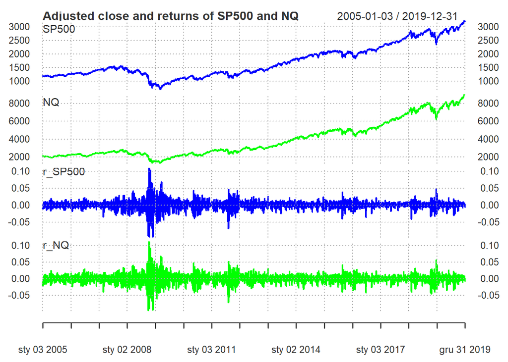

```r
plot(data.US,
     col = c("blue", "green"),
     multi.panel = TRUE,
     major.ticks = "years",
     grid.ticks.on = "years",
     grid.ticks.lty = 3,
     yaxis.same = FALSE,
     main = "Adjusted close and returns of SP500 and NQ")
```

# Example #1 - univariate volatility modelling with GARCH extensions

We will start with estimating the univariate AR(1)-EGARCH(2,1) model for S&P500 and NASDAQ returns (separately) with the `rugarch` package.

First, we prepare the object with model specification:

```r
ar1egarch21mt.spec <-
  ugarchspec(# variance equation
    variance.model = list(model = "eGARCH",
                          garchOrder = c(2,1)),
    # mean equation
    mean.model = list(armaOrder = c(1,0),
                      include.mean = FALSE,
                      archm = TRUE, archpow = 1),
    # assumed distribution of errors
    distribution.model = "std") # std = t-Student
```

Next, we fit both models separately.

```r
SP500.ar1egarch21mt <- ugarchfit(spec = ar1egarch21mt.spec,
                                 data = data.US$r_SP500)

NQ.ar1egarch21mt <- ugarchfit(spec = ar1egarch21mt.spec,
                              data = data.US$r_NQ)
```

Let’s see the results:

```r
SP500.ar1egarch21mt
```

```
##
## *---------------------------------*
## *          GARCH Model Fit        *
## *---------------------------------*
##
## Conditional Variance Dynamics
## -----------------------------------
## GARCH Model  : eGARCH(2,1)
## Mean Model   : ARFIMA(1,0,0)
## Distribution : std
##
## Optimal Parameters
## ------------------------------------
##         Estimate  Std. Error    t value Pr(>|t|)
## ar1    -0.053945    0.015486   -3.48339 0.000495
## archm   0.082717    0.014490    5.70860 0.000000
## omega  -0.308936    0.003760  -82.15478 0.000000
## alpha1 -0.282578    0.010306  -27.42002 0.000000
## alpha2  0.112226    0.012538    8.95063 0.000000
## beta1   0.968474    0.000098 9928.81875 0.000000
## gamma1 -0.027781    0.034682   -0.80101 0.423126
## gamma2  0.202457    0.035788    5.65706 0.000000
## shape   5.637575    0.533185   10.57339 0.000000
##
## Robust Standard Errors:
##         Estimate  Std. Error    t value Pr(>|t|)
## ar1    -0.053945    0.015451   -3.49129 0.000481
## archm   0.082717    0.014975    5.52386 0.000000
## omega  -0.308936    0.004638  -66.61690 0.000000
## alpha1 -0.282578    0.009069  -31.15815 0.000000
## alpha2  0.112226    0.014548    7.71445 0.000000
## beta1   0.968474    0.000107 9076.62584 0.000000
## gamma1 -0.027781    0.036904   -0.75277 0.451585
## gamma2  0.202457    0.040485    5.00084 0.000001
## shape   5.637575    0.557346   10.11504 0.000000
##
## LogLikelihood : 12742.72
##
## Information Criteria
## ------------------------------------
```

[output cut: 52 more lines]

```
## Negative Sign Bias  1.0547 0.2916
## Positive Sign Bias  0.3176 0.7508
## Joint Effect        1.3590 0.7152
##
##
## Adjusted Pearson Goodness-of-Fit Test:
## ------------------------------------
##   group statistic   p-value(g-1)
## 1    20     75.40 0.000000011386
## 2    30     96.14 0.000000004011
## 3    40    103.47 0.000000095255
## 4    50    114.97 0.000000318837
##
##
## Elapsed time : 2.653559
```

```r
NQ.ar1egarch21mt
```

```
##
## *---------------------------------*
## *          GARCH Model Fit        *
## *---------------------------------*
##
## Conditional Variance Dynamics
## -----------------------------------
## GARCH Model  : eGARCH(2,1)
## Mean Model   : ARFIMA(1,0,0)
## Distribution : std
##
## Optimal Parameters
## ------------------------------------
##         Estimate  Std. Error    t value Pr(>|t|)
## ar1    -0.033624    0.014907    -2.2557 0.024091
## archm   0.083696    0.014617     5.7258 0.000000
## omega  -0.311923    0.003322   -93.9034 0.000000
## alpha1 -0.297579    0.004508   -66.0070 0.000000
## alpha2  0.142600    0.011674    12.2151 0.000000
## beta1   0.966845    0.000024 40971.9130 0.000000
## gamma1 -0.057093    0.036873    -1.5484 0.121531
## gamma2  0.196653    0.037398     5.2584 0.000000
## shape   6.750883    0.727381     9.2811 0.000000
##
## Robust Standard Errors:
##         Estimate  Std. Error    t value Pr(>|t|)
## ar1    -0.033624    0.013691    -2.4559 0.014054
## archm   0.083696    0.015265     5.4829 0.000000
## omega  -0.311923    0.003839   -81.2475 0.000000
## alpha1 -0.297579    0.005296   -56.1884 0.000000
## alpha2  0.142600    0.012621    11.2988 0.000000
## beta1   0.966845    0.000026 37849.4660 0.000000
## gamma1 -0.057093    0.036245    -1.5752 0.115212
## gamma2  0.196653    0.038965     5.0469 0.000000
## shape   6.750883    0.789949     8.5460 0.000000
##
## LogLikelihood : 12048.37
##
## Information Criteria
## ------------------------------------
```

[output cut: 52 more lines]

```
## Negative Sign Bias  1.1409 0.2540
## Positive Sign Bias  1.2789 0.2010
## Joint Effect        3.1566 0.3681
##
##
## Adjusted Pearson Goodness-of-Fit Test:
## ------------------------------------
##   group statistic    p-value(g-1)
## 1    20     87.17 0.0000000001047
## 2    30     92.12 0.0000000170949
## 3    40    108.65 0.0000000172727
## 4    50    115.79 0.0000002488507
##
##
## Elapsed time : 1.532522
```

It looks like the model is acceptable for both series.

To simplify the further analyses, let’s create an object including only returns series of SP500 and NASDAQ.

```r
data.US.ret <- data.US[, 3:4]
tail(data.US.ret)
```

```
##                   r_SP500          r_NQ
## 2019-12-23  0.00086576869  0.0023155828
## 2019-12-24 -0.00019546732  0.0008078308
## 2019-12-26  0.00511506232  0.0077339715
## 2019-12-27  0.00003398432 -0.0017493512
## 2019-12-30 -0.00579759624 -0.0067544621
## 2019-12-31  0.00294169057  0.0029700322
```

Now, we can analyze correlation coefficient between SP500 and NQ returns.

First, let’s make a scatterplot of returns:

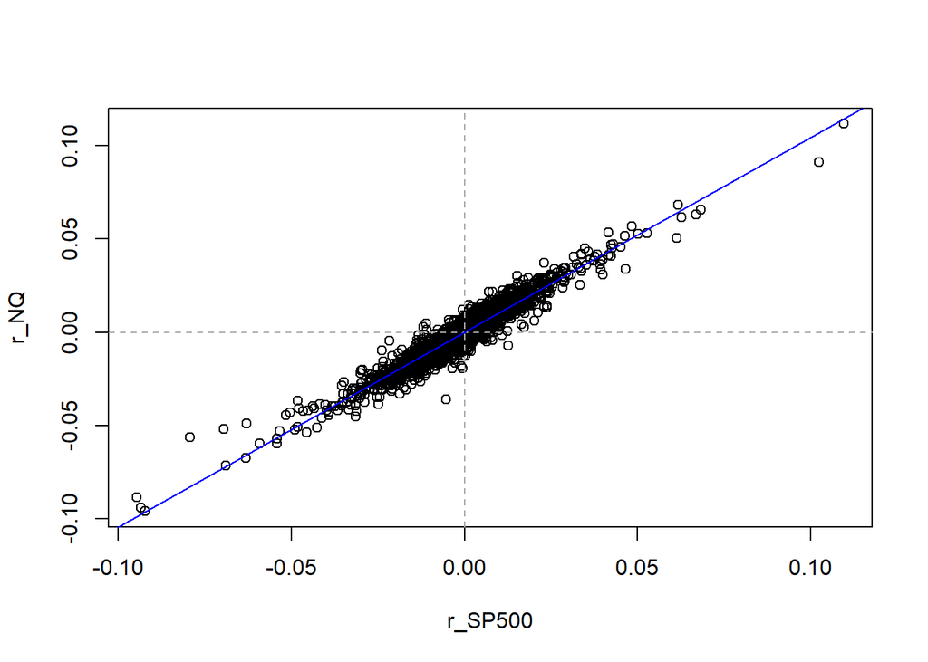

```r
plot( coredata(data.US.ret$r_SP500),
      coredata(data.US.ret$r_NQ),
      xlab = "r_SP500", ylab = "r_NQ")
# reference lines at 0
abline(h = 0, v = 0, lty = 2, col = "darkgray")
# regression line
abline(lm(r_NQ ~ r_SP500,
          data = data.US.ret),
       col = "blue")
```

The same plot with created with the `ggplot2` package:

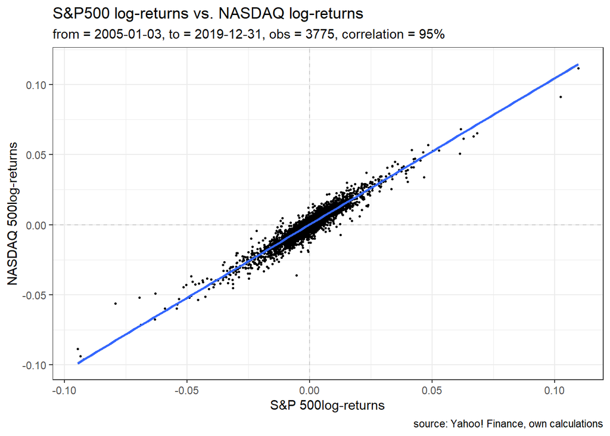

```r
data.US.ret %>%
  as_tibble() %>%
  ggplot(aes(r_SP500, r_NQ)) +
  geom_vline(xintercept = 0, linetype = "dashed", col = "gray80") +
  geom_hline(yintercept = 0, linetype = "dashed", col = "gray80") +
  geom_point(size = 0.5) +
  geom_smooth(method = lm) +
  theme_bw() +
  labs(
    title = "S&P500 log-returns vs. NASDAQ log-returns",
    subtitle = paste0("from = ",
                      index(data.US.ret) %>% head(1),
                      ", to = ",
                      index(data.US.ret) %>% tail(1),
                      ", obs = ",
                      nrow(data.US.ret),
                      ", correlation = ",
                      cor(data.US.ret)[1,2] %>% scales::percent()),
    caption = "source: Yahoo! Finance, own calculations",
    x = "S&P 500log-returns",
    y = "NASDAQ 500log-returns"
  )
```

The plot indicates a strong positive correlation.

Next, let’s calculate the correlation coefficient:

```r
cor(data.US.ret$r_SP500, data.US.ret$r_NQ)
```

```
##             r_NQ
## r_SP500 0.954673
```

In the next examples, we will apply some multivariate GARCH models.

# Example #2 - DCC model with rmgarch package

DCC (Dynamic Conditional Correlation) GARCH for SPP500 and NASDAQ returns with a more flexible estimation function from the`rmgarch` package.

DCC specification - lets use DCC(2,1). For both series we use the AR(1)-EGARCH(2,1)-t specification (the model with in-mean element does not converge).

Let’s define a common specification for volatilities in the same way as we did for univariate models:

```r
ar1egarch21t.spec <- ugarchspec(# variance equation
                                variance.model = list(model = "eGARCH",
                                                      garchOrder = c(2, 1)),
                                # mean equation
                                mean.model = list(armaOrder = c(1, 0),
                                                  include.mean = FALSE),
                                # assumed distribution of errors
                                distribution.model = "std") # std = t-Student
```

Specification for the whole multivariate model:

```r
dcc21.spec <- dccspec(# we need to use 2 specifications as we model 2 variables
                     uspec = multispec( c(ar1egarch21t.spec,
                                          ar1egarch21t.spec) ),
                     dccOrder = c(2, 1)) # dynamic corelation model order
```

Finally, we fit the model:

```r
dcc.fit <- dccfit(dcc21.spec,    # specification
                  data = data.US.ret) # data
```

Now, we can analyze the results:

```r
dcc.fit
```

```
##
## *---------------------------------*
## *          DCC GARCH Fit          *
## *---------------------------------*
##
## Distribution         :  mvnorm
## Model                :  DCC(2,1)
## No. Parameters       :  20
## [VAR GARCH DCC UncQ] : [0+16+3+1]
## No. Series           :  2
## No. Obs.             :  3775
## Log-Likelihood       :  28500.59
## Av.Log-Likelihood    :  7.55
##
## Optimal Parameters
## -----------------------------------
##                   Estimate  Std. Error   t value Pr(>|t|)
## [r_SP500].ar1    -0.040503    0.015366   -2.6360 0.008390
## [r_SP500].omega  -0.301380    0.003205  -94.0292 0.000000
## [r_SP500].alpha1 -0.277372    0.027692  -10.0162 0.000000
## [r_SP500].alpha2  0.094054    0.027613    3.4061 0.000659
## [r_SP500].beta1   0.967732    0.000137 7058.7198 0.000000
## [r_SP500].gamma1 -0.021049    0.014532   -1.4485 0.147491
## [r_SP500].gamma2  0.193212    0.025843    7.4763 0.000000
## [r_SP500].shape   6.200073    0.644668    9.6175 0.000000
## [r_NQ].ar1       -0.019304    0.014085   -1.3705 0.170525
## [r_NQ].omega     -0.304624    0.002706 -112.5609 0.000000
## [r_NQ].alpha1    -0.288322    0.022958  -12.5589 0.000000
## [r_NQ].alpha2     0.121933    0.023458    5.1978 0.000000
## [r_NQ].beta1      0.966201    0.000113 8514.7212 0.000000
## [r_NQ].gamma1    -0.053720    0.016878   -3.1829 0.001458
## [r_NQ].gamma2     0.189878    0.025498    7.4468 0.000000
## [r_NQ].shape      7.657892    0.932222    8.2147 0.000000
## [Joint]dcca1      0.032216    0.013800    2.3345 0.019571
## [Joint]dcca2      0.030250    0.015786    1.9162 0.055340
## [Joint]dccb1      0.895043    0.018987   47.1395 0.000000
##
## Information Criteria
## ---------------------
##
## Akaike       -15.089
## Bayes        -15.056
## Shibata      -15.089
## Hannan-Quinn -15.077
##
##
## Elapsed time : 5.328961
```

- `[r_SP500]` - parameters for SP500 model
- `[r_NQ]` - parameters for NASDAQ model
- `[Joint]` - conditional correlation parameters

(it also follows GARCH-type(2,1) model)

Plot method:

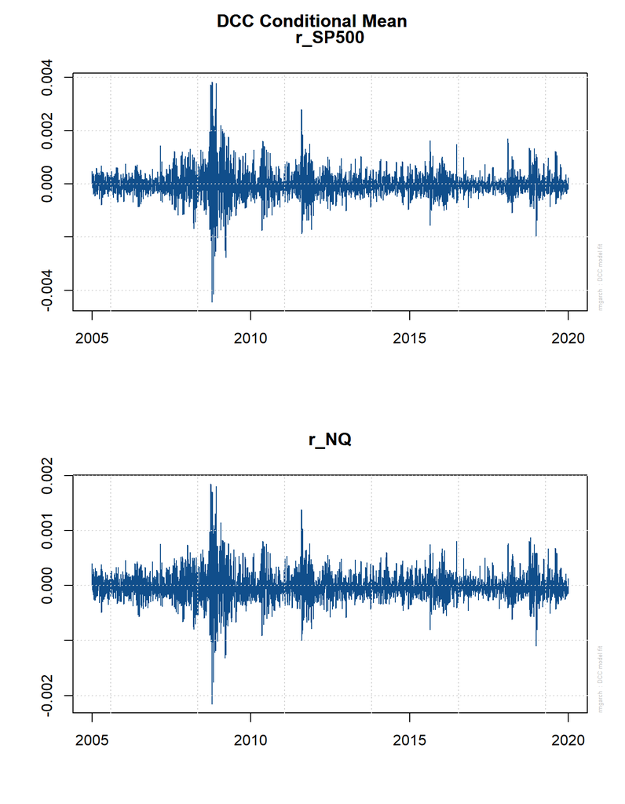

```r
plot(dcc.fit, which = 1)
```

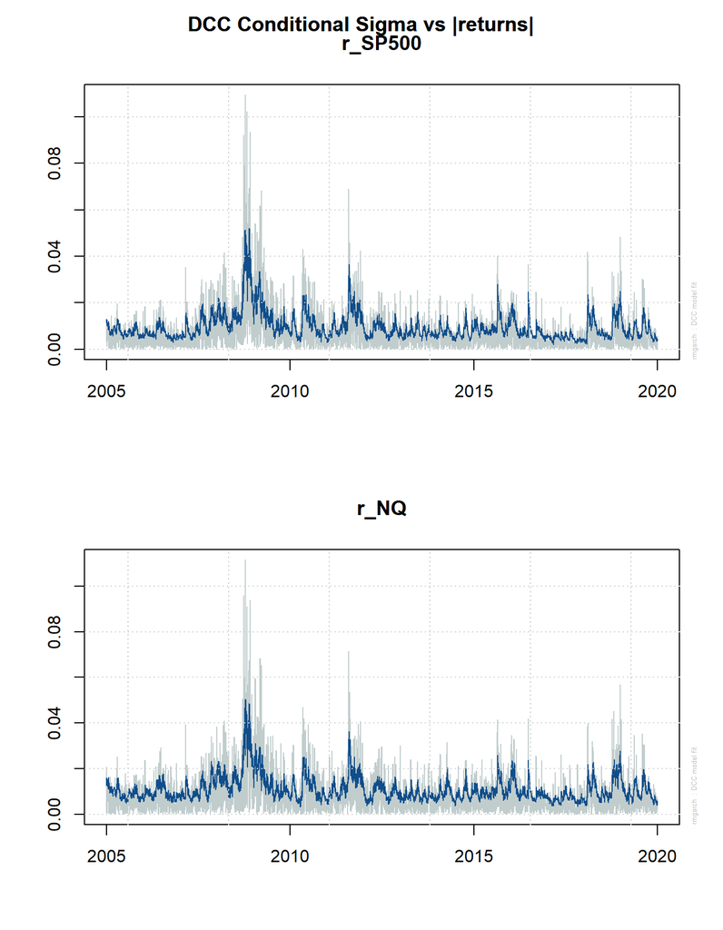

```r
plot(dcc.fit, which = 2)
```

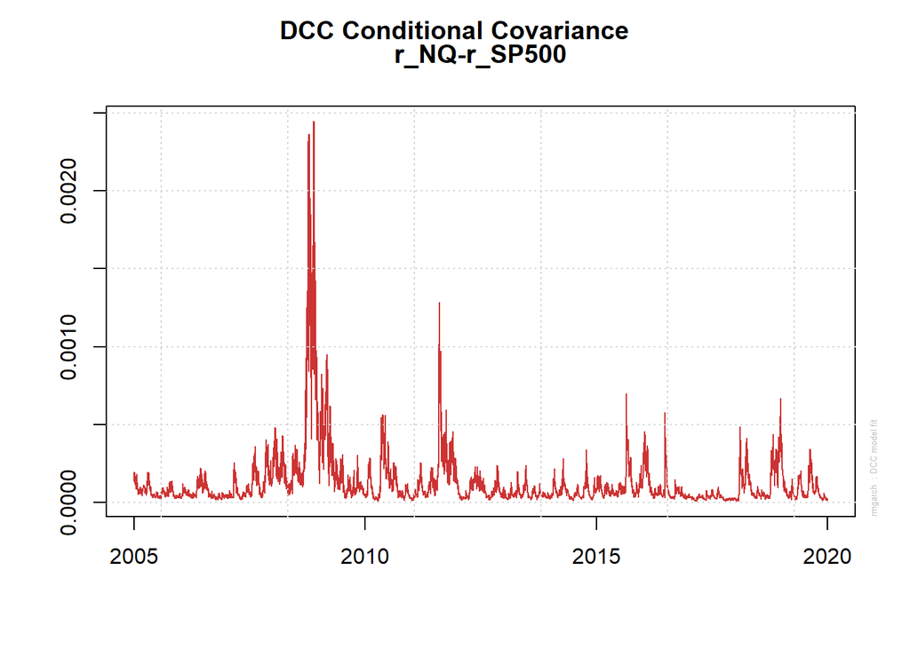

```r
plot(dcc.fit, which = 3)
```

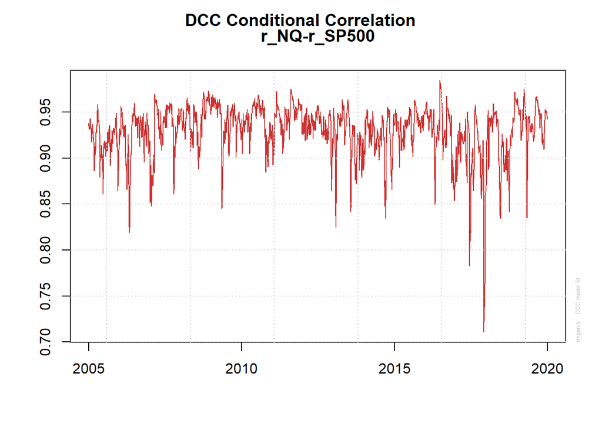

```r
plot(dcc.fit, which = 4)
```

When calling in the console, make a plot selection (ESC to exit):

- 1: Conditional Mean (vs Realized Returns)
- 2: Conditional Sigma (vs Realized Absolute Returns)
- 3: Conditional Covariance
- 4: Conditional Correlation

Further recommendation: the `mgarchBEKK` package, more details here:

- https://cran.r-project.org/web/packages/mgarchBEKK/mgarchBEKK.pdf

Forecasting the the DCC model:

```r
dcc.forecasts <-
  dccforecast(dcc.fit,
              n.ahead = 1,
              n.roll  = 0)
```

1-step ahead forecast of DCC coefficient

```r
dcc.forecasts@mforecast$R
```

```
## [[1]]
## , , 1
##
##           [,1]      [,2]
## [1,] 1.0000000 0.9455464
## [2,] 0.9455464 1.0000000
```

```r
dcc.forecasts@mforecast$R[[1]][, , 1][1, 2]
```

```
## [1] 0.9455464
```

```r
dcc.forecasts@mforecast$R[[1]][, , 1][2, 1]
```

```
## [1] 0.9455464
```

# Example #3 - EMWA approach on another dataset

The SIGMA matrix with the EWMA approach.

We will use the data with returns of Hang-Seng index (`HK`) and Nikkei index (`JP`).

```r
hkjp <- readRDS("data/hkjp.rds")
hkjp %>% glimpse()
```

```
## Rows: 713
## Columns: 3
## $ Date <date> 2006-01-05, 2006-01-06, 2006-01-10, 2006-01-11, 2006-01-12, 2006…
## $ HK   <dbl> 15271.13, 15344.44, 15569.91, 15650.88, 15719.37, 15787.97, 15777…
## $ JP   <dbl> 16425.37, 16428.21, 16124.35, 16363.59, 16445.19, 16454.95, 16268…
```

Creating log returns:

```r
hkjp$rHK <- diff.xts(log(hkjp$HK))
hkjp$rJP <- diff.xts(log(hkjp$JP))
```

Plot of returns:

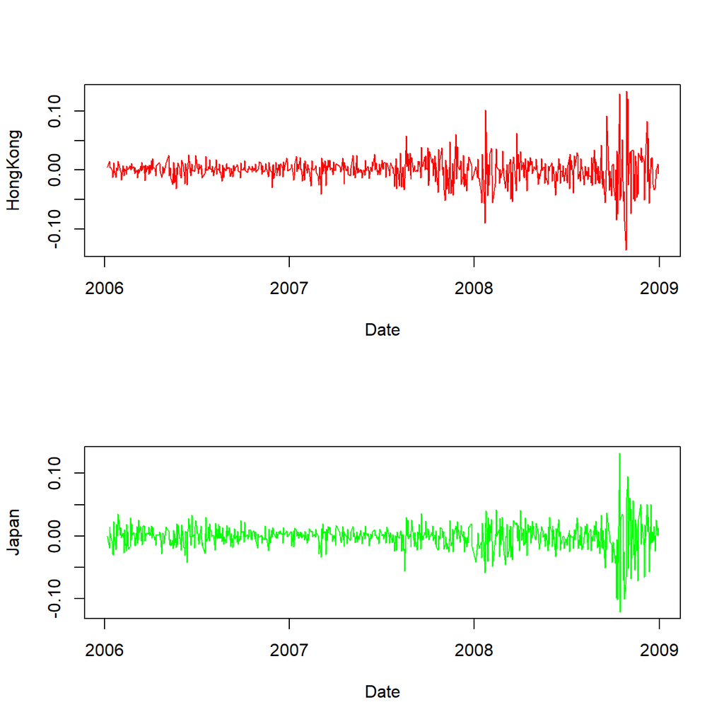

```r
par(mfrow = c(2, 1))
plot(hkjp$Date, hkjp$rHK,
     type = 'l', lwd = 1, col = 'red',   ylab = 'HongKong', xlab = 'Date')
plot(hkjp$Date, hkjp$rJP,
     type = 'l', lwd = 1, col = 'green', ylab = 'Japan',   xlab = 'Date')
```

```r
par(mfrow = c(1, 1))
```

or alternatively with the `gglot2` package:

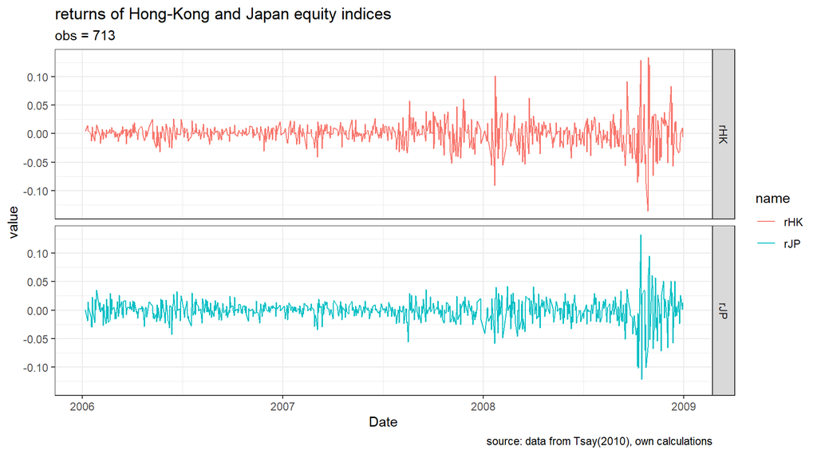

```r
hkjp %>%
  dplyr::select(Date, rHK, rJP) %>%
  pivot_longer(!Date) %>%
  ggplot(aes(Date, value, col = name)) +
  geom_line() +
  facet_grid(rows = vars(name)) +
  theme_bw() +
  labs(
    title = "returns of Hong-Kong and Japan equity indices",
    subtitle = paste0("obs = ", nrow(hkjp)),
    caption = "source: data from Tsay(2010), own calculations"
  )
```

Estimating `GARCH(1,1)` model with the `ugarchFit()` function:

```r
spec <- ugarchspec(
  variance.model = list(model = "sGARCH",
                        garchOrder = c(1, 1)),
  mean.model = list(armaOrder = c(0, 0), include.mean = T),
  distribution.model = "norm")

rHK.garch11 <- ugarchfit(spec = spec, data = na.omit(hkjp$rHK))
rHK.garch11@model$pars
```

```
##                  Level Fixed Include Estimate            LB        UB
## mu       0.00104003113     0       1        1 -9.863100e-03 0.0098631
## ar       0.00000000000     0       0        0            NA        NA
## ma       0.00000000000     0       0        0            NA        NA
## arfima   0.00000000000     0       0        0            NA        NA
## archm    0.00000000000     0       0        0            NA        NA
## mxreg    0.00000000000     0       0        0            NA        NA
## omega    0.00000400497     0       1        1  2.220446e-16 0.4902408
## alpha1   0.14563879911     0       1        1  0.000000e+00 1.0000000
## beta1    0.85300347020     0       1        1  0.000000e+00 1.0000000
## gamma    0.00000000000     0       0        0            NA        NA
## eta1     0.00000000000     0       0        0            NA        NA
## eta2     0.00000000000     0       0        0            NA        NA
## delta    0.00000000000     0       0        0            NA        NA
## lambda   0.00000000000     0       0        0            NA        NA
## vxreg    0.00000000000     0       0        0            NA        NA
## skew     0.00000000000     0       0        0            NA        NA
## shape    0.00000000000     0       0        0            NA        NA
## ghlambda 0.00000000000     0       0        0            NA        NA
## xi       0.00000000000     0       0        0            NA        NA
```

```r
rHK.garch11@fit$tval
```

```
##        mu     omega    alpha1     beta1
##  2.241626  1.237342  5.509569 33.034113
```

```r
rHK.garch11@fit$coef
```

```
##            mu         omega        alpha1         beta1
## 0.00104003113 0.00000400497 0.14563879911 0.85300347020
```

```r
rHK.garch11@fit$se.coef
```

```
## [1] 0.000463962897 0.000003236753 0.026433791286 0.025821897390
```

```r
rHK.garch11
```

```
##
## *---------------------------------*
## *          GARCH Model Fit        *
## *---------------------------------*
##
## Conditional Variance Dynamics
## -----------------------------------
## GARCH Model  : sGARCH(1,1)
## Mean Model   : ARFIMA(0,0,0)
## Distribution : norm
##
## Optimal Parameters
## ------------------------------------
##         Estimate  Std. Error  t value Pr(>|t|)
## mu      0.001040    0.000464   2.2416 0.024986
## omega   0.000004    0.000003   1.2373 0.215960
## alpha1  0.145639    0.026434   5.5096 0.000000
## beta1   0.853003    0.025822  33.0341 0.000000
##
## Robust Standard Errors:
##         Estimate  Std. Error  t value Pr(>|t|)
## mu      0.001040    0.000429  2.42488 0.015313
## omega   0.000004    0.000007  0.56112 0.574713
## alpha1  0.145639    0.034267  4.25013 0.000021
## beta1   0.853003    0.039772 21.44735 0.000000
##
## LogLikelihood : 1938.362
##
## Information Criteria
## ------------------------------------
##
## Akaike       -5.4336
## Bayes        -5.4079
## Shibata      -5.4337
## Hannan-Quinn -5.4237
##
## Weighted Ljung-Box Test on Standardized Residuals
## ------------------------------------
##                         statistic p-value
## Lag[1]                     0.3560  0.5507
```

[output cut: 37 more lines]

```
## Negative Sign Bias  0.8896 0.37400
## Positive Sign Bias  1.8155 0.06988   *
## Joint Effect       11.0044 0.01170  **
##
##
## Adjusted Pearson Goodness-of-Fit Test:
## ------------------------------------
##   group statistic p-value(g-1)
## 1    20     63.34  0.000001135
## 2    30     71.46  0.000019123
## 3    40     79.46  0.000139072
## 4    50    101.62  0.000015141
##
##
## Elapsed time : 0.05627298
```

```r
rJP.garch11 <- ugarchfit(spec = spec, data = na.omit(hkjp$rJP))
rJP.garch11@model$pars
```

```
##                   Level Fixed Include Estimate            LB         UB
## mu       0.000016364999     0       1        1 -8.670365e-02 0.08670365
## ar       0.000000000000     0       0        0            NA         NA
## ma       0.000000000000     0       0        0            NA         NA
## arfima   0.000000000000     0       0        0            NA         NA
## archm    0.000000000000     0       0        0            NA         NA
## mxreg    0.000000000000     0       0        0            NA         NA
## omega    0.000004500506     0       1        1  2.220446e-16 0.39489156
## alpha1   0.125326127134     0       1        1  0.000000e+00 0.99999999
## beta1    0.862954982622     0       1        1  0.000000e+00 0.99999999
## gamma    0.000000000000     0       0        0            NA         NA
## eta1     0.000000000000     0       0        0            NA         NA
## eta2     0.000000000000     0       0        0            NA         NA
## delta    0.000000000000     0       0        0            NA         NA
## lambda   0.000000000000     0       0        0            NA         NA
## vxreg    0.000000000000     0       0        0            NA         NA
## skew     0.000000000000     0       0        0            NA         NA
## shape    0.000000000000     0       0        0            NA         NA
## ghlambda 0.000000000000     0       0        0            NA         NA
## xi       0.000000000000     0       0        0            NA         NA
```

```r
rJP.garch11@fit$tval
```

```
##          mu       omega      alpha1       beta1
##  0.03531706  1.37830290  5.73511706 38.17211145
```

```r
rJP.garch11@fit$coef
```

```
##             mu          omega         alpha1          beta1
## 0.000016364999 0.000004500506 0.125326127134 0.862954982622
```

```r
rJP.garch11@fit$se.coef
```

```
## [1] 0.000463373785 0.000003265252 0.021852409624 0.022606949155
```

```r
rJP.garch11
```

```
##
## *---------------------------------*
## *          GARCH Model Fit        *
## *---------------------------------*
##
## Conditional Variance Dynamics
## -----------------------------------
## GARCH Model  : sGARCH(1,1)
## Mean Model   : ARFIMA(0,0,0)
## Distribution : norm
##
## Optimal Parameters
## ------------------------------------
##         Estimate  Std. Error   t value Pr(>|t|)
## mu      0.000016    0.000463  0.035317  0.97183
## omega   0.000005    0.000003  1.378303  0.16811
## alpha1  0.125326    0.021852  5.735117  0.00000
## beta1   0.862955    0.022607 38.172111  0.00000
##
## Robust Standard Errors:
##         Estimate  Std. Error   t value Pr(>|t|)
## mu      0.000016    0.000426  0.038421 0.969352
## omega   0.000005    0.000007  0.626392 0.531058
## alpha1  0.125326    0.030583  4.097926 0.000042
## beta1   0.862955    0.032381 26.649769 0.000000
##
## LogLikelihood : 1985.048
##
## Information Criteria
## ------------------------------------
##
## Akaike       -5.5647
## Bayes        -5.5391
## Shibata      -5.5648
## Hannan-Quinn -5.5548
##
## Weighted Ljung-Box Test on Standardized Residuals
## ------------------------------------
##                         statistic p-value
## Lag[1]                     0.6203  0.4309
```

[output cut: 37 more lines]

```
## Negative Sign Bias   0.284 0.77647
## Positive Sign Bias   1.452 0.14701
## Joint Effect        15.365 0.00153 ***
##
##
## Adjusted Pearson Goodness-of-Fit Test:
## ------------------------------------
##   group statistic p-value(g-1)
## 1    20     30.98      0.04060
## 2    30     41.54      0.06174
## 3    40     47.10      0.17493
## 4    50     50.08      0.43036
##
##
## Elapsed time : 0.05409789
```

Standardized residuals:

```r
str(rHK.garch11)
```

[output not shown]

[output cut: 35 more lines]

[output not shown]

```r
rHK.stdres <- rHK.garch11@fit$residuals / rHK.garch11@fit$sigma
rJP.stdres <- rJP.garch11@fit$residuals / rJP.garch11@fit$sigma
```

Analysis of standardized residuals:

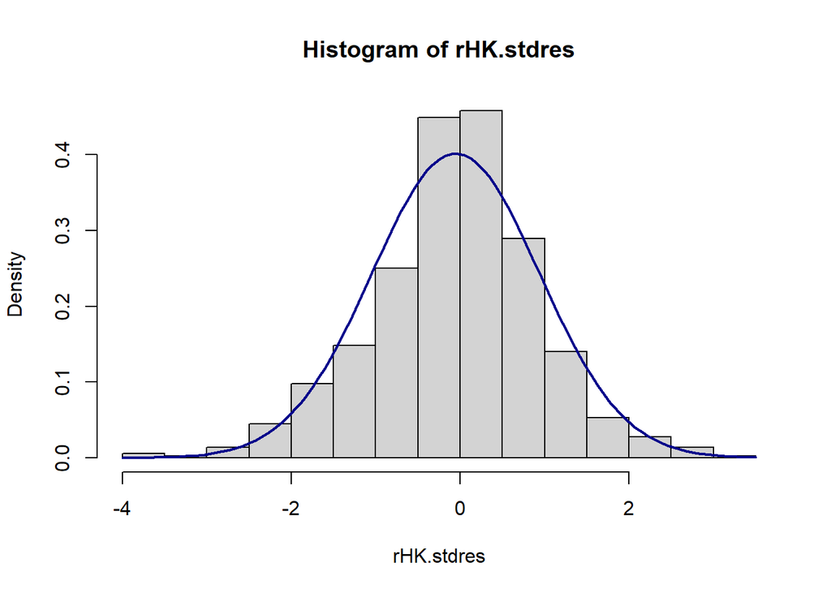

```r
hist(rHK.stdres, breaks = 20, prob = T)
curve(dnorm(x,
            mean = mean(rHK.stdres, na.rm = T),
            sd = sd(rHK.stdres, na.rm = T)),
      col = "darkblue", lwd = 2, add = TRUE)
```

```r
basicStats(rHK.stdres)
```

```
##             rHK.stdres
## nobs        712.000000
## NAs           0.000000
## Minimum      -3.652709
## Maximum       3.092808
## 1. Quartile  -0.616694
## 3. Quartile   0.548864
## Mean         -0.053595
## Median       -0.011075
## Sum         -38.159805
## SE Mean       0.037220
## LCL Mean     -0.126670
## UCL Mean      0.019480
## Variance      0.986374
## Stdev         0.993164
## Skewness     -0.213444
## Kurtosis      0.655642
```

```r
jarque.bera.test(rHK.stdres)
```

```
##
##  Jarque Bera Test
##
## data:  rHK.stdres
## X-squared = 18.585, df = 2, p-value = 0.0000921
```

```r
ArchTest(rHK.stdres, lags = 5)
```

```
##
##  ARCH LM-test; Null hypothesis: no ARCH effects
##
## data:  rHK.stdres
## Chi-squared = 10.98, df = 5, p-value = 0.05177
```

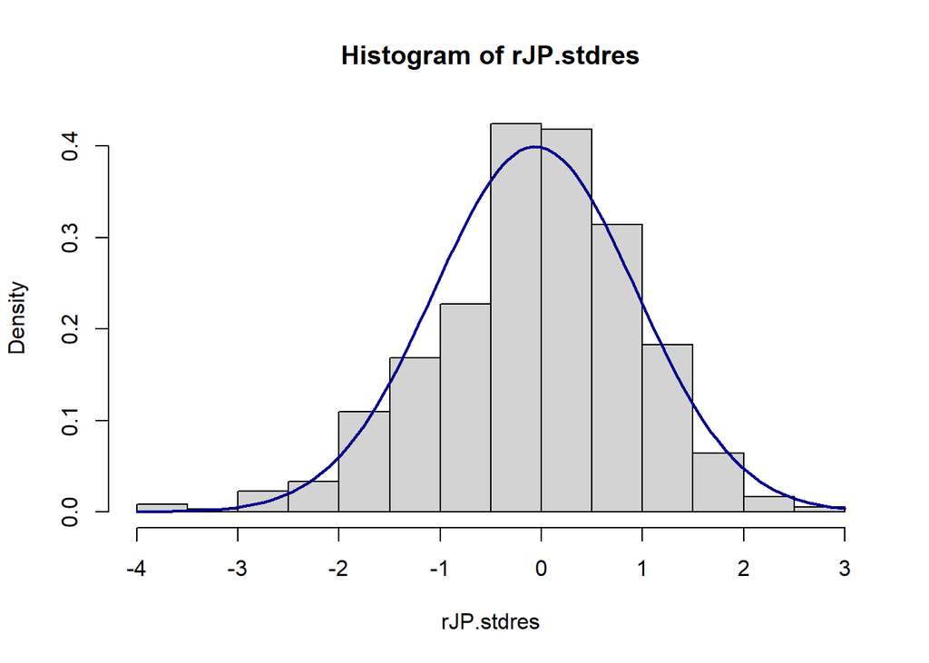

```r
hist(rJP.stdres, breaks = 20, prob = T)
curve(dnorm(x,
            mean = mean(rJP.stdres,na.rm = T),
            sd = sd(rJP.stdres,na.rm = T)),
      col = "darkblue", lwd = 2, add = TRUE)
```

```r
basicStats(rJP.stdres)
```

```
##             rJP.stdres
## nobs        712.000000
## NAs           0.000000
## Minimum      -3.821153
## Maximum       2.574387
## 1. Quartile  -0.626452
## 3. Quartile   0.623901
## Mean         -0.061668
## Median        0.002381
## Sum         -43.907771
## SE Mean       0.037411
## LCL Mean     -0.135117
## UCL Mean      0.011780
## Variance      0.996478
## Stdev         0.998238
## Skewness     -0.423517
## Kurtosis      0.444342
```

```r
jarque.bera.test(rJP.stdres)
```

```
##
##  Jarque Bera Test
##
## data:  rJP.stdres
## X-squared = 27.491, df = 2, p-value = 0.000001073
```

```r
ArchTest(rJP.stdres,lags = 5)
```

```
##
##  ARCH LM-test; Null hypothesis: no ARCH effects
##
## data:  rJP.stdres
## Chi-squared = 8.0375, df = 5, p-value = 0.1542
```

Plot of annulized conditional standard deviation:

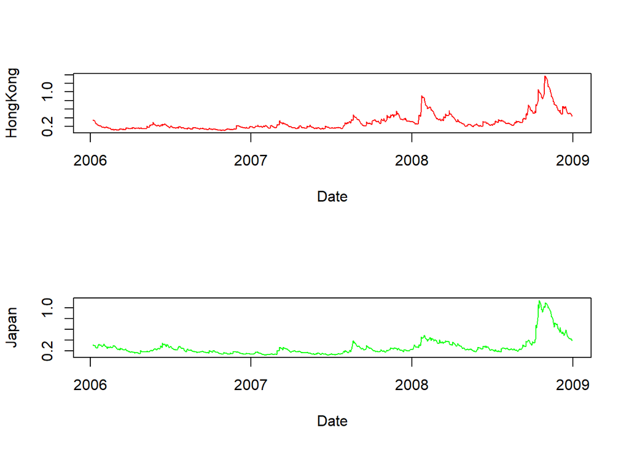

```r
par(mfrow = c(2, 1))
plot(hkjp$Date[2:length(hkjp$Date)],
     sqrt(252) * rHK.garch11@fit$sigma,
     type = 'l', lwd = 1, col = 'red', ylab = 'HongKong', xlab = 'Date')
plot(hkjp$Date[2:length(hkjp$Date)],
     sqrt(252) * rJP.garch11@fit$sigma,
     type = 'l', lwd = 1, col = 'green', ylab = 'Japan',  xlab = 'Date')
```

```r
par(mfrow = c(1, 1))
```

The same plot created with the `ggplot2` package:

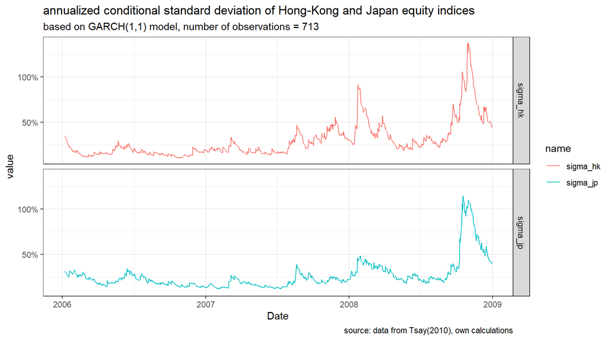

```r
tibble(
  Date = hkjp$Date[2:length(hkjp$Date)],
  sigma_hk = sqrt(252) * rHK.garch11@fit$sigma,
  sigma_jp = sqrt(252) * rJP.garch11@fit$sigma,
) %>%
  pivot_longer(!Date) %>%
  ggplot(aes(Date, value, col = name)) +
  geom_line() +
  facet_grid(rows = vars(name)) +
  theme_bw() +
  scale_y_continuous(labels = scales::percent) +
  labs(
    title = "annualized conditional standard deviation of Hong-Kong and Japan equity indices",
    subtitle = paste0("based on GARCH(1,1) model, number of observations = ", nrow(hkjp)),
    caption = "source: data from Tsay(2010), own calculations"
  )
```

Estimating the sigma matrix using the EWMA:

```r
str(hkjp)
```

```
## 'data.frame':    713 obs. of  5 variables:
##  $ Date: Date, format: "2006-01-05" "2006-01-06" ...
##  $ HK  : num  15271 15344 15570 15651 15719 ...
##  $ JP  : num  16425 16428 16124 16364 16445 ...
##  $ rHK : num  NA 0.00479 0.01459 0.00519 0.00437 ...
##  $ rJP : num  NA 0.000173 -0.018669 0.014728 0.004974 ...
```

```r
hkjp.mat <- as.matrix(hkjp[2:length(hkjp$rHK), c("rHK", "rJP")])
ewma.results <- getSigmaEWMA(hkjp.mat, lambda = 0.9305)
```

EWMA estimates of variances:

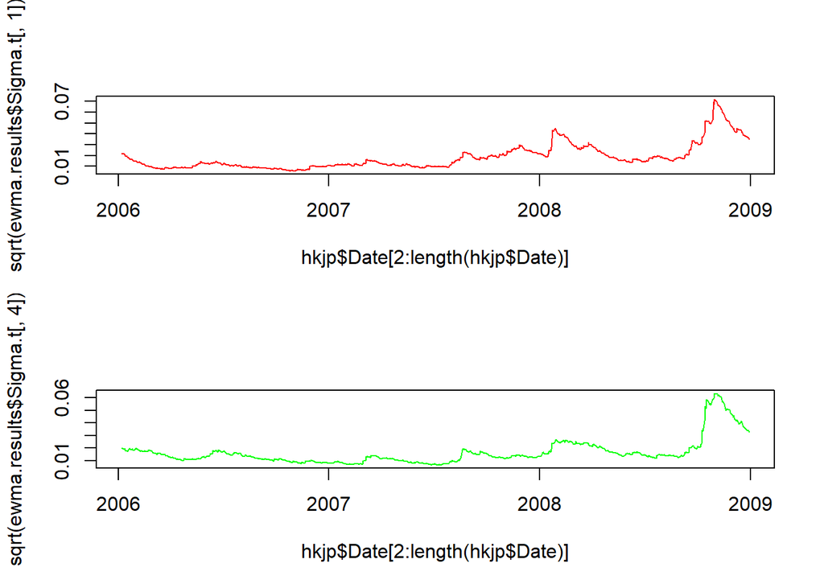

```r
par(mfrow = c(2, 1))
plot(hkjp$Date[2:length(hkjp$Date)],
     sqrt(ewma.results$Sigma.t[, 1]),
     type = 'l', col = 'red' )
plot(hkjp$Date[2:length(hkjp$Date)],
     sqrt(ewma.results$Sigma.t[, 4]),
     type = 'l', col = 'green')
```

```r
par(mfrow = c(1, 1))
```

We can use estimates of variances to create a plot of annualized conditional standard deviations of EWMA method:

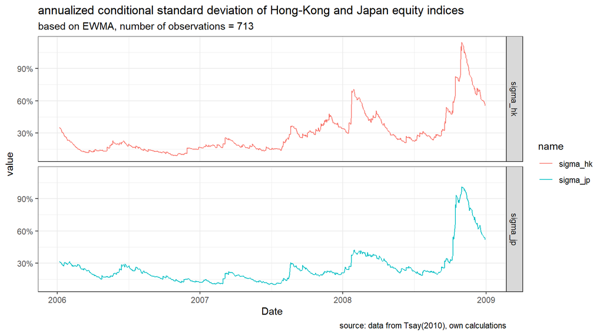

```r
tibble(
  Date = hkjp$Date[2:length(hkjp$Date)],
  sigma_hk = sqrt(252) * sqrt(ewma.results$Sigma.t[, 1]),
  sigma_jp = sqrt(252) * sqrt(ewma.results$Sigma.t[, 4]),
) %>%
  pivot_longer(!Date) %>%
  ggplot(aes(Date, value, col = name)) +
  geom_line() +
  facet_grid(rows = vars(name)) +
  theme_bw() +
  scale_y_continuous(labels = scales::percent) +
  labs(
    title = "annualized conditional standard deviation of Hong-Kong and Japan equity indices",
    subtitle = paste0("based on EWMA, number of observations = ", nrow(hkjp)),
    caption = "source: data from Tsay(2010), own calculations"
  )
```

EWMA estimate of covariance:

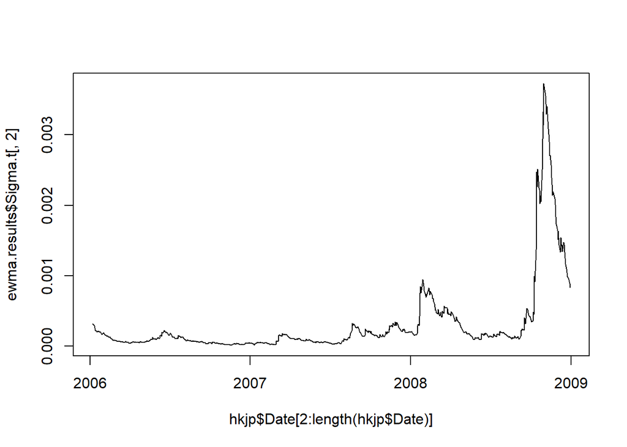

```r
plot(hkjp$Date[2:length(hkjp$Date)],
     ewma.results$Sigma.t[,2],
     type = 'l', col = 'black' )
```

EWMA estimate of correlation:

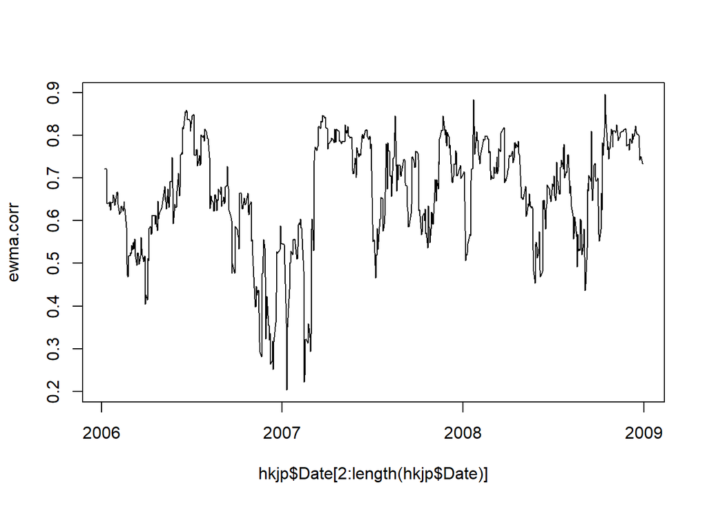

```r
ewma.corr <- ewma.results$Sigma.t[, 2] /
  (sqrt(ewma.results$Sigma.t[, 1] * ewma.results$Sigma.t[, 4]))
plot(hkjp$Date[2:length(hkjp$Date)],
     ewma.corr,
     type = 'l', col = 'black')
```

# Example #4 - CCC model with ccgarch package

The CCC-GARCH(1,1) model with the the `ccgarch` package.

data: `hjka`

```r
a <- c(0.003, 0.005)
A <- diag(c(0.2, 0.3))
B <- diag(c(0.75, 0.6))
R <- matrix(c(1, 0, 0, 1), 2, 2)
```

```r
str(hkjp)
```

```
## 'data.frame':    713 obs. of  5 variables:
##  $ Date: Date, format: "2006-01-05" "2006-01-06" ...
##  $ HK  : num  15271 15344 15570 15651 15719 ...
##  $ JP  : num  16425 16428 16124 16364 16445 ...
##  $ rHK : num  NA 0.00479 0.01459 0.00519 0.00437 ...
##  $ rJP : num  NA 0.000173 -0.018669 0.014728 0.004974 ...
```

```r
hkjp.mat <- as.matrix(hkjp[2:length(hkjp$Date), c(4, 5)])
```

```r
ccc.results <- eccc.estimation(a,
                               A,
                               B,
                               R,
                               hkjp.mat,
                               model  = 'diagonal',
                               method = 'BFGS')
str(ccc.results)
```

```
## List of 5
##  $ out      : num [1:4, 1:7] 0.00001019 0.00000227 0.00000254 0.00000257 0.00000657 ...
##   ..- attr(*, "dimnames")=List of 2
##   .. ..$ : chr [1:4] "para.estimates" "Inv. Hessian" "Outer Prod." "Robust"
##   .. ..$ : chr [1:7] "a1" "a2" "A11" "A22" ...
##  $ h        : num [1:712, 1:2] 0.000485 0.000408 0.000375 0.00032 0.000273 ...
##  $ std.resid: num [1:712, 1:2] 0.217 0.722 0.268 0.244 0.264 ...
##   ..- attr(*, "dimnames")=List of 2
##   .. ..$ : chr [1:712] "2" "3" "4" "5" ...
##   .. ..$ : chr [1:2] "rHK" "rJP"
##  $ opt      :List of 5
##   ..$ par        : num [1:7] -0.00319 -0.00256 -0.39691 0.32987 -0.90152 ...
##   ..$ value      : num -4126
##   ..$ counts     : Named int [1:2] 174 30
##   .. ..- attr(*, "names")= chr [1:2] "function" "gradient"
##   ..$ convergence: int 0
##   ..$ message    : NULL
##  $ para.mat :List of 4
##   ..$ a: num [1:2] 0.00001019 0.00000657
##   ..$ A: num [1:2, 1:2] 0.158 0 0 0.109
##   ..$ B: num [1:2, 1:2] 0.813 0 0 0.866
##   ..$ R: num [1:2, 1:2] 1 0.668 0.668 1
```

CCC results:

```r
ccc.results$para.mat$R
```

```
##           [,1]      [,2]
## [1,] 1.0000000 0.6683739
## [2,] 0.6683739 1.0000000
```

```r
ccc.results$para.mat$A
```

```
##           [,1]      [,2]
## [1,] 0.1575336 0.0000000
## [2,] 0.0000000 0.1088162
```

```r
ccc.results$para.mat$B
```

```
##          [,1]      [,2]
## [1,] 0.812733 0.0000000
## [2,] 0.000000 0.8658195
```

Volatilities (conditional standard deviations):

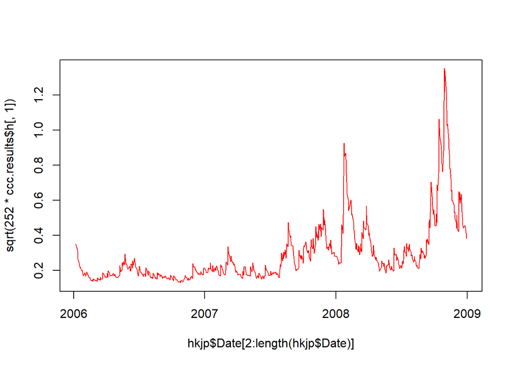

```r
# 1. HK
plot(hkjp$Date[2:length(hkjp$Date)],
     sqrt(252*ccc.results$h[, 1]),
     type = 'l', col = 'red')
```

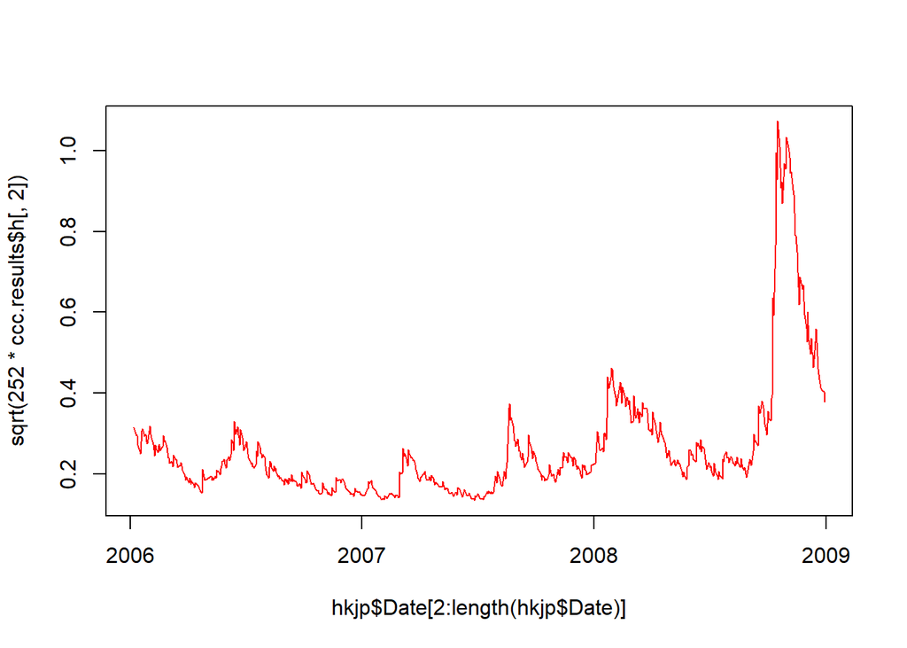

```r
# 2. JP
plot(hkjp$Date[2:length(hkjp$Date)],
     sqrt(252*ccc.results$h[, 2]),
     type = 'l', col = 'red')
```

# Example #5 - DCC model with ccgarch package

The DCC-GARCH(1,1) model with the `ccgarch` package.

data: `hkjp`

Preparing the matrices:

```r
str(hkjp)
```

```
## 'data.frame':    713 obs. of  5 variables:
##  $ Date: Date, format: "2006-01-05" "2006-01-06" ...
##  $ HK  : num  15271 15344 15570 15651 15719 ...
##  $ JP  : num  16425 16428 16124 16364 16445 ...
##  $ rHK : num  NA 0.00479 0.01459 0.00519 0.00437 ...
##  $ rJP : num  NA 0.000173 -0.018669 0.014728 0.004974 ...
```

```r
hkjp.mat <- as.matrix(hkjp[2:length(hkjp$Date), c(4, 5)])
str(hkjp.mat)
```

```
##  num [1:712, 1:2] 0.00479 0.01459 0.00519 0.00437 0.00435 ...
##  - attr(*, "dimnames")=List of 2
##   ..$ : chr [1:712] "2" "3" "4" "5" ...
##   ..$ : chr [1:2] "rHK" "rJP"
```

Plot:

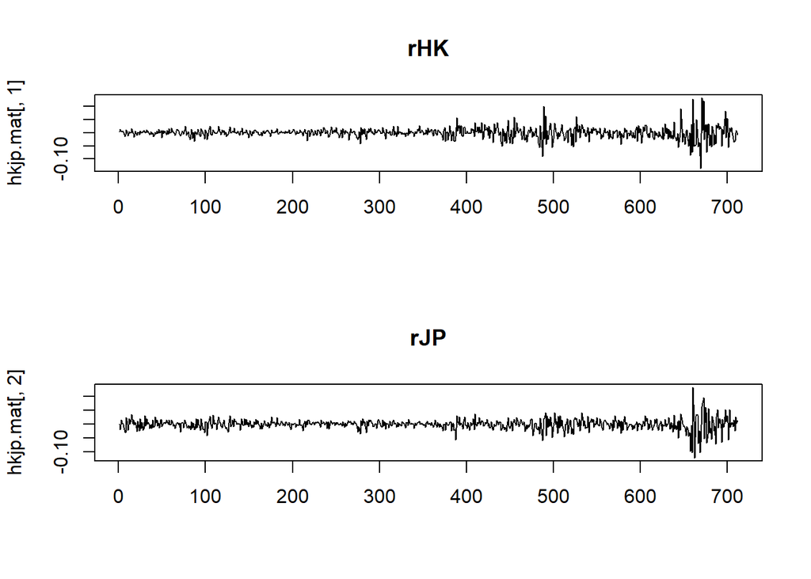

```r
par(mfrow = c(2, 1))
plot(hkjp.mat[, 1], type = 'l', xlab = "", main = "rHK")
plot(hkjp.mat[, 2], type = 'l', xlab = "", main = "rJP")
```

```r
par(mfrow = c(1, 1))
```

Descriptive statistics:

```r
basicStats(hkjp.mat[, 1] * 100)
```

```
##             X..hkjp.mat...1..100
## nobs                  712.000000
## NAs                     0.000000
## Minimum               -13.582024
## Maximum                13.406809
## 1. Quartile            -0.817874
## 3. Quartile             0.917528
## Mean                   -0.009863
## Median                  0.084885
## Sum                    -7.022527
## SE Mean                 0.082978
## LCL Mean               -0.172775
## UCL Mean                0.153049
## Variance                4.902408
## Stdev                   2.214138
## Skewness                0.245428
## Kurtosis                8.337262
```

```r
basicStats(hkjp.mat[, 2] * 100)
```

```
##             X..hkjp.mat...2..100
## nobs                  712.000000
## NAs                     0.000000
## Minimum               -12.111026
## Maximum                13.234585
## 1. Quartile            -0.939768
## 3. Quartile             0.811634
## Mean                   -0.086704
## Median                  0.004267
## Sum                   -61.732999
## SE Mean                 0.074473
## LCL Mean               -0.232917
## UCL Mean                0.059510
## Variance                3.948916
## Stdev                   1.987188
## Skewness               -0.431569
## Kurtosis                8.310595
```

```r
nrow(hkjp.mat)
```

```
## [1] 712
```

Estimation of the DCC model:

```r
dcc.para <- c(0.01, 0.98)
a <- c(0.003, 0.005)
A <- diag(c(0.2, 0.3))
B <- diag(c(0.75, 0.6))
dcc.results <- dcc.estimation(inia     = a,
                              iniA     = A,
                              iniB     = B,
                              ini.dcc  = dcc.para,
                              dvar     = hkjp.mat,
                              model    = "diagonal",
                              method   = "BFGS",
                              gradient = 1,
                              message  = 1)
```

```
## *  Estimation has been completed.                              *
## *  The outputs are saved in a list with components:            *
## *    out    : the estimates and their standard errors          *
## *    loglik : the value of the log-likelihood at the estimates *
## *    h      : a matrix of estimated conditional variances      *
## *    DCC    : a matrix of DCC estimates                        *
## *    std.resid : a matrix of the standardised residuals        *
## *    first  : the results of the first stage estimation        *
## *    second : the results of the second stage estimation       *
```

```r
str(dcc.results)
```

```
## List of 7
##  $ out      : num [1:2, 1:8] 0.00000296 0.00000176 0.0000024 0.02972751 0.14520333 ...
##   ..- attr(*, "dimnames")=List of 2
##   .. ..$ : chr [1:2] "estimates" "std.err"
##   .. ..$ : chr [1:8] "a1" "a2" "A11" "A22" ...
##  $ loglik   : num 4124
##  $ h        : num [1:712, 1:2] 0.000495 0.000432 0.000406 0.000356 0.000312 ...
##  $ DCC      : num [1:712, 1:4] 1 1 1 1 1 1 1 1 1 1 ...
##  $ std.resid: num [1:712, 1:2] 0.215 0.702 0.257 0.231 0.247 ...
##   ..- attr(*, "dimnames")=List of 2
##   .. ..$ : chr [1:712] "2" "3" "4" "5" ...
##   .. ..$ : chr [1:2] "rHK" "rJP"
##  $ first    :List of 5
##   ..$ par        : num [1:6] -0.00172 -0.00155 0.38106 0.30692 -0.92752 ...
##   ..$ value      : num -3919
##   ..$ counts     : Named int [1:2] 222 32
##   .. ..- attr(*, "names")= chr [1:2] "function" "gradient"
##   ..$ convergence: int 0
##   ..$ message    : NULL
##  $ second   :List of 7
##   ..$ par             : num [1:2] 0.0183 0.9577
##   ..$ value           : num 497
##   ..$ counts          : Named num [1:2] 41 9
##   .. ..- attr(*, "names")= chr [1:2] "function" "gradient"
##   ..$ convergence     : int 0
##   ..$ message         : NULL
##   ..$ outer.iterations: int 2
##   ..$ barrier.value   : num 0.00000204
```

```r
str(dcc.results$DCC)
```

```
##  num [1:712, 1:4] 1 1 1 1 1 1 1 1 1 1 ...
```

```r
str(dcc.results$h)
```

```
##  num [1:712, 1:2] 0.000495 0.000432 0.000406 0.000356 0.000312 ...
```

```r
str(dcc.results$std.resid)
```

```
##  num [1:712, 1:2] 0.215 0.702 0.257 0.231 0.247 ...
##  - attr(*, "dimnames")=List of 2
##   ..$ : chr [1:712] "2" "3" "4" "5" ...
##   ..$ : chr [1:2] "rHK" "rJP"
```

Plot of DCC:

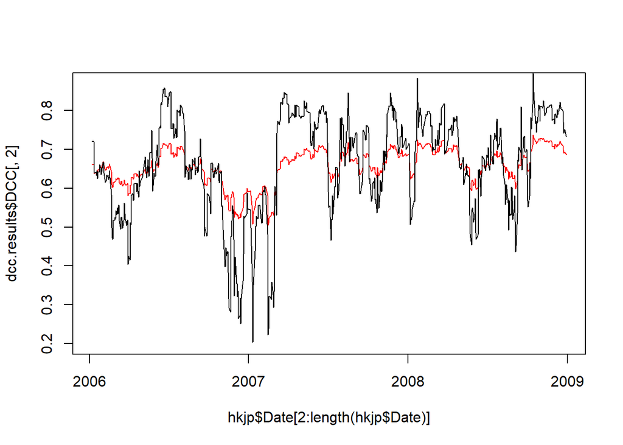

```r
# rHK vs rJP
plot(hkjp$Date[2:length(hkjp$Date)],
     dcc.results$DCC[, 2],
     type = 'l', col = "red", ylim = c(0.2, 0.87))
# together with the EWMA correlation
lines(hkjp$Date[2:length(hkjp$Date)],
      ewma.corr,
      type = 'l', col = 'black')
```

Plots of annualized volatility (annualized conditional standard deviation):

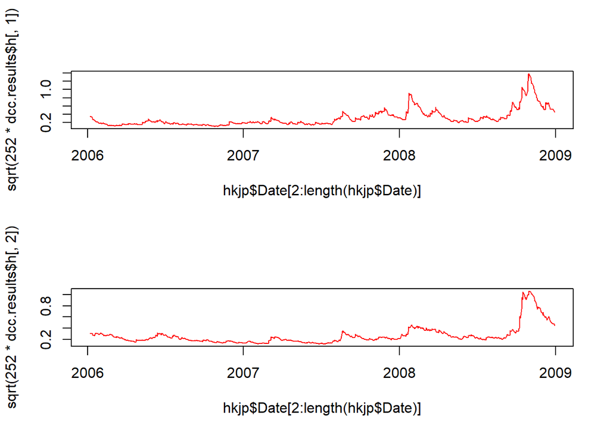

```r
# 1. rHK
par(mfrow = c(2, 1))
plot(hkjp$Date[2:length(hkjp$Date)],
     sqrt(252 * dcc.results$h[, 1]),
     type = 'l', col = 'red')
# 2. rJP
plot(hkjp$Date[2:length(hkjp$Date)],
     sqrt(252 * dcc.results$h[, 2]),
     type = 'l', col = 'red')
```

```r
par(mfrow = c(1, 1))
```

# Exercises 14

Perform similar analyses for:

- SP500 (ticker: SPX)
- BTCUSD (ticker: BTC-USD)

or any other two time series with returns of financial assets.

## Exercises 14.1

Estimate and analyze the sigma matrix using the EWMA approach

## Exercises 14.2

Estimate and interpret the CCC GARCH(1,1) model.

## Exercises 14.3

Estimate and interpret the DCC GARCH(1,1) model.

## Exercises 14.4

Estimate and interpret the DCC GARCH(p,q) model that best fits to the data.